# Wthite Wine EDA by Matheus Maciel

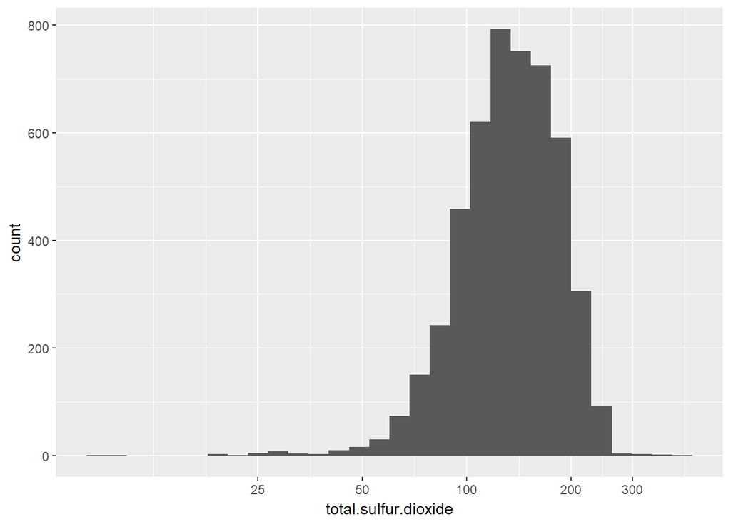

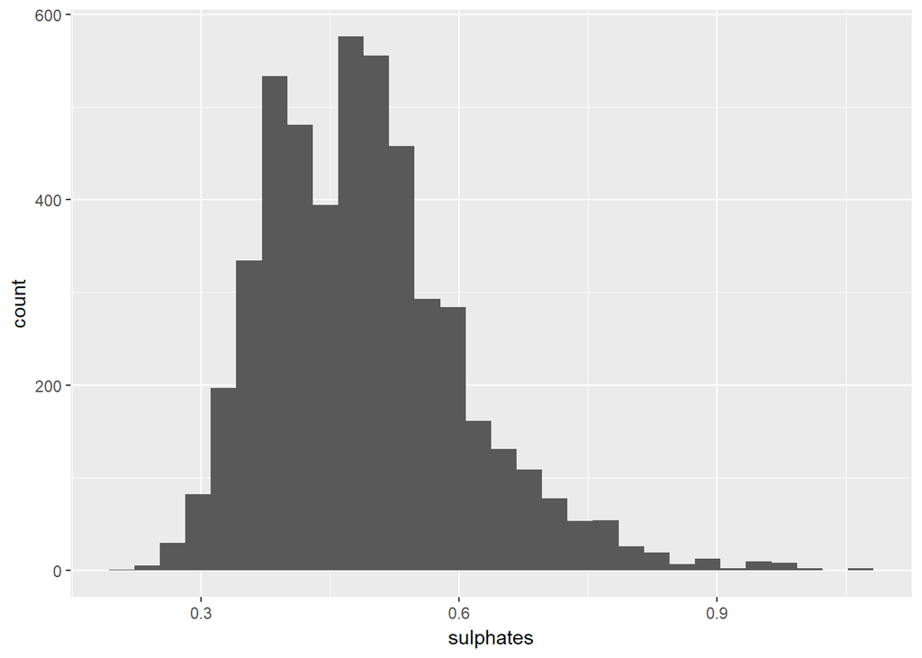

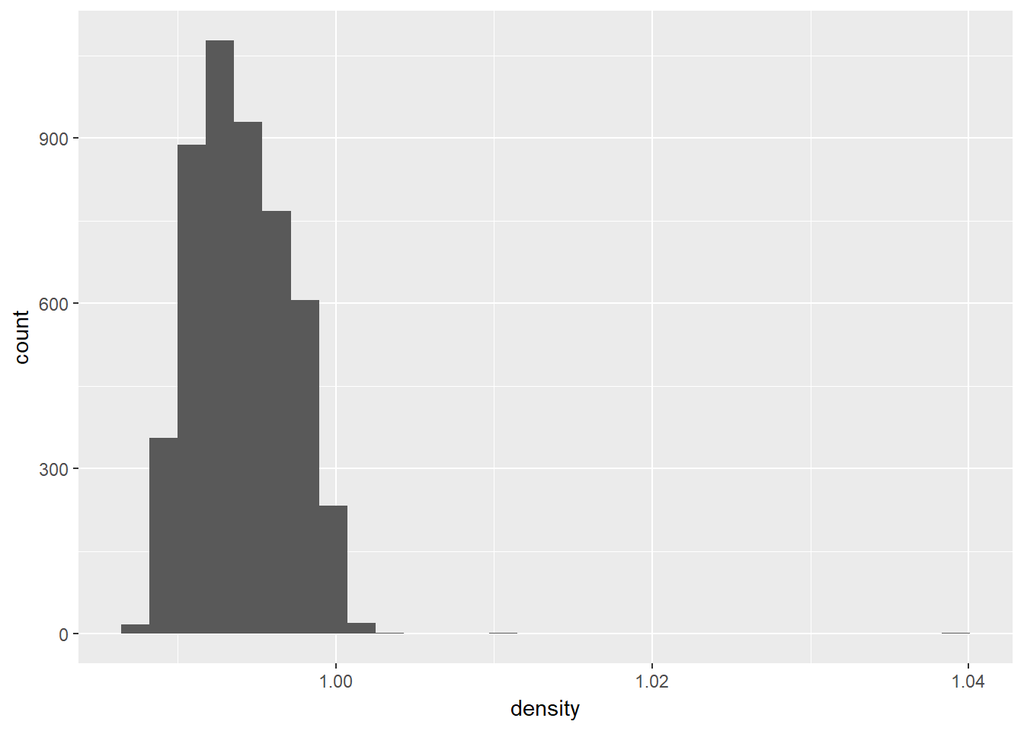

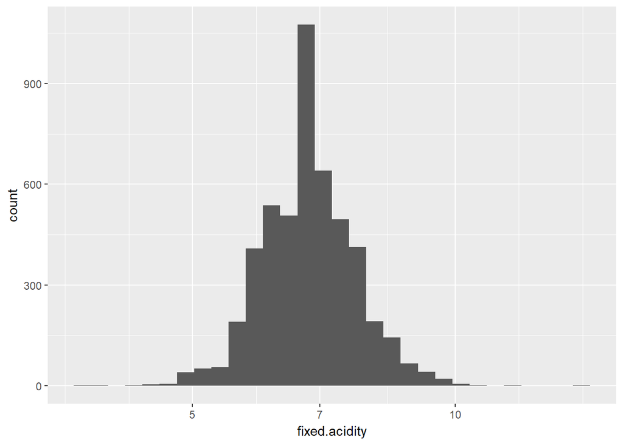

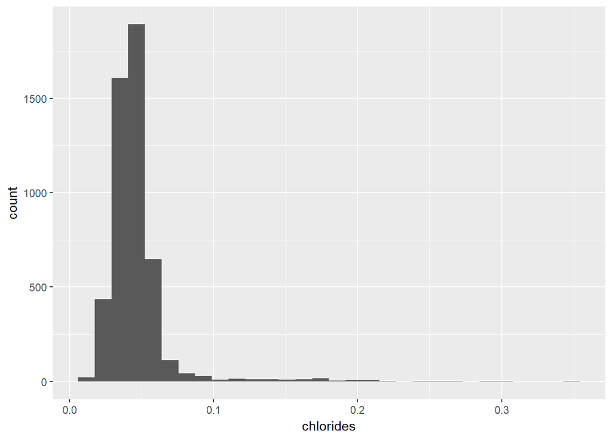

Como esperado os valores de *density* estão próximo de 1 g/cm^3. Além disso, grande parte dos valores de *fixed.acidity* estão entre 5 e 10 g/dm^3 com pico em 7 g/dm^3. Por último, os valores de *chlorides* estão entre 0 e 0,1 g/dm^3 que numericamente é uma variação pequena mas dentro desse contexto pode ter influência na qualidade do vinho.

# Univariate Analysis

### What is the structure of your dataset?

Existem 4898 variantes de vinho branco descritas por 12 atributos (*fixed.acidity*, *volatile.acidity*, *citric.acid*, *residual.sugar*, *chlorides*, *free.sulfur.dioxide*, *total.sulfur.dioxide*, *density*, *pH*, *sulphates*, *alcohol* and *quality*). Todos os atributos com exceção de *quality* são variáveis númericas sendo 9 deles densidades (g/dm<sup>3</sup> ou mg/dm<sup>3</sup>). *quality* é uma variável qualitativa ordinal que vai de 0 a 10 onde 0 é a pior qualidade e 10 a melhor.

Observações interessantes:

- Menos de 4% das variantes foram de qualidade maior que 7 sendo que nenhuma dela tem qualidade 10.
- A porcentagem média de *alcohol* é 10.51% semelhante a mediana de 10,40%.
- A maioria das variantes tem pH 3,14

### What is/are the main feature(s) of interest in your dataset?

O principal atributo desse conjunto de dados é a qualidade da variante de vinho branco. O objetivo dessa análise é descobrir quais dos outro atributos são úteis para prever a qualidado do vinho. Como já foi dito na seção anterior, alguns atributos parecem ter relação mais direta com o sabor do vinho que pode levar a melhores avaliações de qualidade.

### What other features in the dataset do you think will help support your investigation into your feature(s) of interest?

As duas variáveis que indicam os níveis de dióxido de enxofre (SO2) podem ajudar na tarefa de previsão da qualidade dado que a partir de certos níveis a presença da substância começa a influenciar o cheiro e sabor do vinho.

### Did you create any new variables from existing variables in the dataset?

Não.

### Of the features you investigated, were there any unusual distributions? Did you perform any operations on the data to tidy, adjust, or change the form of the data? If so, why did you do this?

Vários atributos possuem valores muito grandes que tornam as distribuições enviesadas para a direita. Em todos esse casos, os valores foram transformados usando a função log na base 10. Dessa forma foi possível ver o formato dos dados sem a influência “completa” dos outliers. No geral, todas os atributos transformados parecem seguir distribuição normal com exceção de *residual.sugar* que parece seguir uma distribuição bimodal.

# Bivariate Plots Section

Dos atributos citados na seção anterior apenas o nível de álcool possui correlção considerar média-alta com a qualidade do vinho. No caso de *volatile.acidity* e *total.sulfur.dioxide* os valores de correção não chegam a ser médios mas indicam que os eles podem ajudar na previsão da qualidade. É interessante ressaltar que a correlação entre *alcohol* e *total.sulfur.dioxide* é de -0,45 que pode ser considerada média-alta então talvez não seja interessante ou necessário usa-las em conjunto.

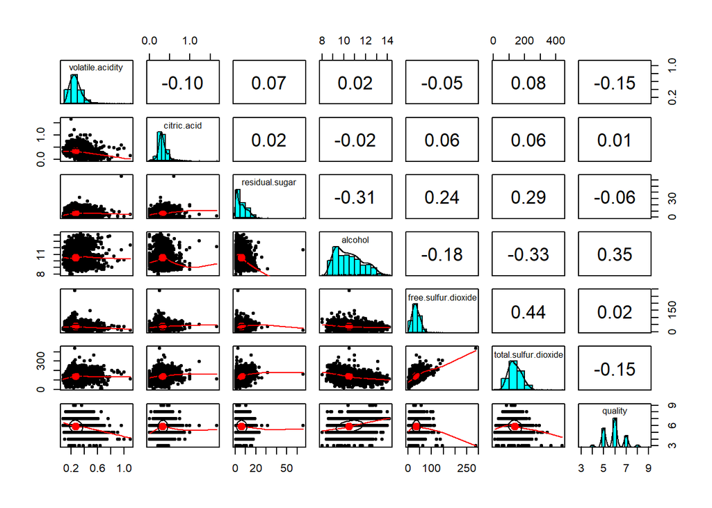

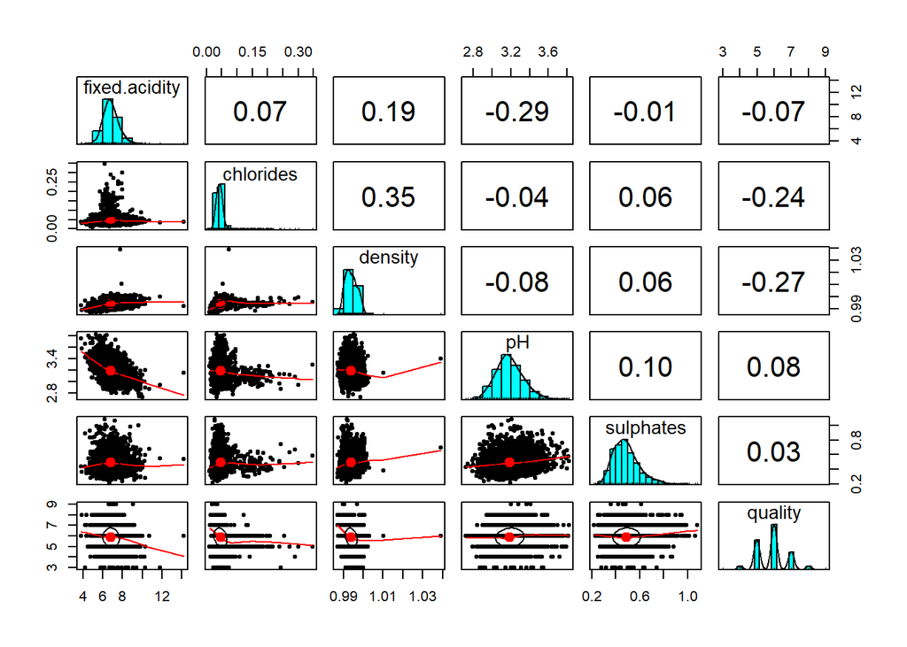

Dentre os outros atributos, dois deles possuem correlações que podem indicar sua utilidade na previsão da qualidade. São eles *density* e *chlorides*. Os outros atributos não possuem correlação significantes para o obejtivo desse relatório. Assim como *alcohol* e *total.sulfur.dioxide*, *density* e *chlorides* possuem correlação baixa-média entre si, logo existe a possibilidade da não utilização de um deles. Para facilitar a visualição, o gráfico abaixo contém as correlações entre as variáveis selecionadas.

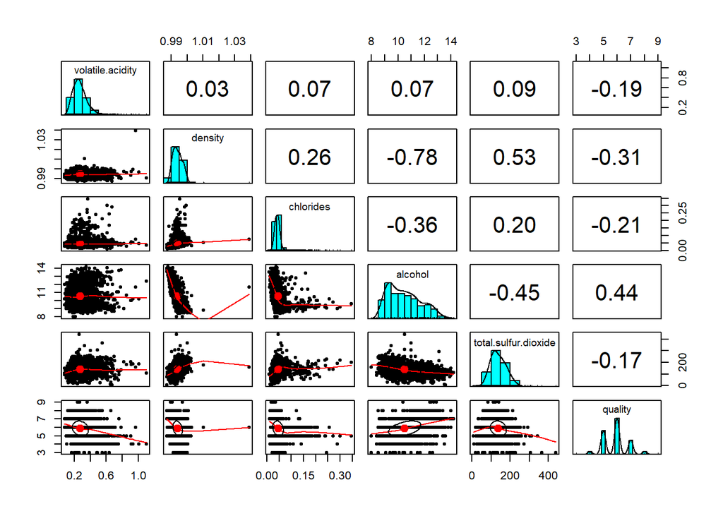

Como comentado acima, existe correlção entre os atributos selecionados. Destaque para a correlação entre *density* e *alcohol* que pode ser considerada alta.

Em seguida, as variáveis selecionadas são comparadas com a qualidade.

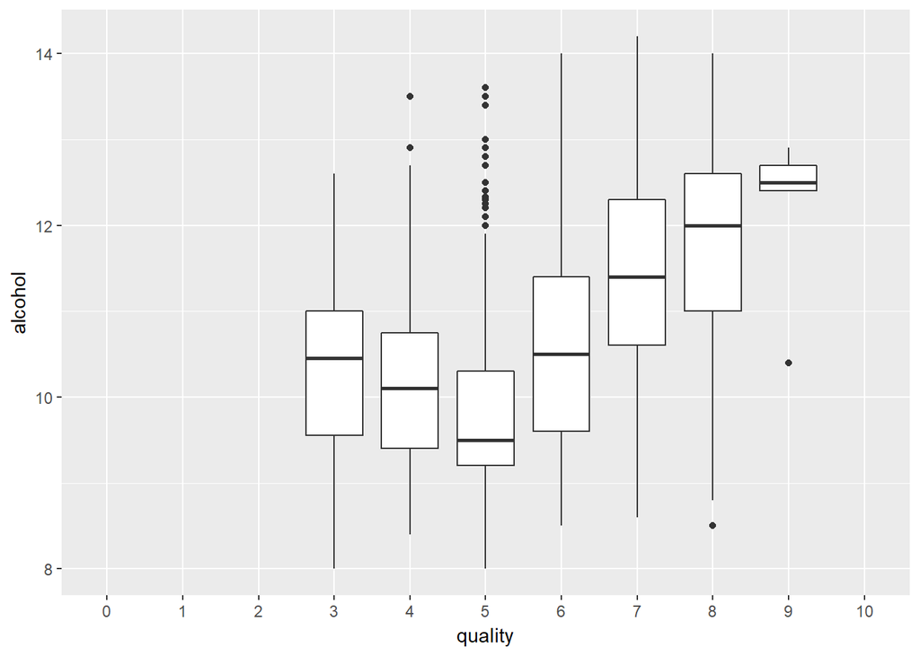

```
##
##  Descriptive statistics by group
## group: 0
## NULL
## --------------------------------------------------------
## group: 1
## NULL
## --------------------------------------------------------
## group: 2
## NULL
## --------------------------------------------------------
## group: 3
##    vars  n  mean   sd median trimmed  mad min  max range skew kurtosis
## X1    1 20 10.35 1.22  10.45   10.34 1.19   8 12.6   4.6 0.02    -0.83
##      se
## X1 0.27
## --------------------------------------------------------
## group: 4
##    vars   n  mean sd median trimmed  mad min  max range skew kurtosis   se
## X1    1 163 10.15  1   10.1   10.08 1.04 8.4 13.5   5.1  0.7     0.15 0.08
## --------------------------------------------------------
## group: 5
##    vars    n mean   sd median trimmed  mad min  max range skew kurtosis
## X1    1 1457 9.81 0.85    9.5    9.71 0.74   8 13.6   5.6 1.08     1.07
##      se
## X1 0.02
## --------------------------------------------------------
## group: 6
##    vars    n  mean   sd median trimmed  mad min max range skew kurtosis
## X1    1 2198 10.58 1.15   10.5   10.52 1.33 8.5  14   5.5  0.4    -0.72
##      se
## X1 0.02
## --------------------------------------------------------
## group: 7
##    vars   n  mean   sd median trimmed  mad min  max range skew kurtosis
## X1    1 880 11.37 1.25   11.4   11.42 1.33 8.6 14.2   5.6 -0.3    -0.56
##      se
## X1 0.04
## --------------------------------------------------------
## group: 8
##    vars   n  mean   sd median trimmed  mad min max range  skew kurtosis
## X1    1 175 11.64 1.28     12   11.78 1.19 8.5  14   5.5 -0.89     0.01
##     se
## X1 0.1
## --------------------------------------------------------
## group: 9
##    vars n  mean   sd median trimmed mad  min  max range  skew kurtosis
## X1    1 5 12.18 1.01   12.5   12.18 0.3 10.4 12.9   2.5 -0.98    -1.03
##      se
## X1 0.45
## --------------------------------------------------------
## group: 10
## NULL
```

É possível notar que a menor mediana possui tendência decrescente até qualidade 5 quando atinge o valor 9.5%, entretanto, para vinhos com qualidade acima de 5 existe uma certa tendência que indica o crescimento do percentual de *alcohol* com o crescimento da qualidade do vinho alcançando o valor 12,5%. É interessante notar que o *box* para a qualidade 9 é menor que os demais, possivelmente devido a quantidade reduzida de variantes de vinho nessa categoria.

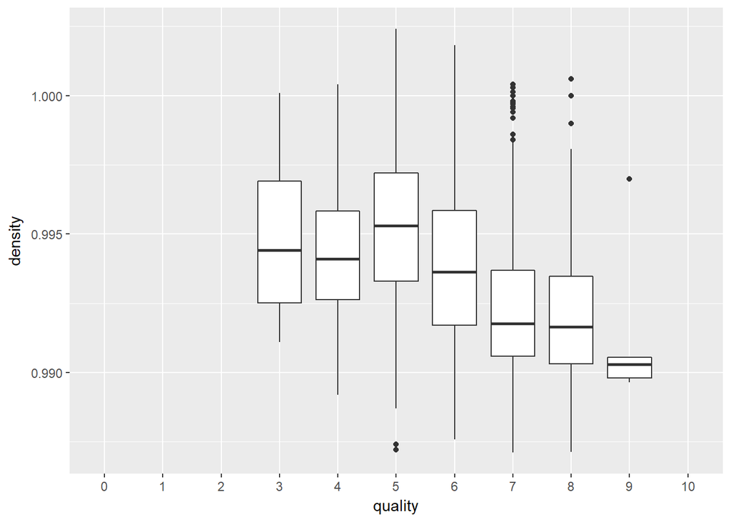

```
##
##  Descriptive statistics by group
## group: 0
## NULL
## --------------------------------------------------------
## group: 1
## NULL
## --------------------------------------------------------
## group: 2
## NULL
## --------------------------------------------------------
## group: 3
##    vars  n mean sd median trimmed mad  min max range skew kurtosis se
## X1    1 20 0.99  0   0.99    0.99   0 0.99   1  0.01 0.31    -1.24  0
## --------------------------------------------------------
## group: 4
##    vars   n mean sd median trimmed mad  min max range skew kurtosis se
## X1    1 163 0.99  0   0.99    0.99   0 0.99   1  0.01 0.18    -0.62  0
## --------------------------------------------------------
## group: 5
##    vars    n mean sd median trimmed mad  min max range skew kurtosis se
## X1    1 1457    1  0      1       1   0 0.99   1  0.02 0.06    -0.58  0
## --------------------------------------------------------
## group: 6
##    vars    n mean sd median trimmed mad  min  max range skew kurtosis se
## X1    1 2198 0.99  0   0.99    0.99   0 0.99 1.04  0.05 1.85    21.89  0
## --------------------------------------------------------
## group: 7
##    vars   n mean sd median trimmed mad  min max range skew kurtosis se
## X1    1 880 0.99  0   0.99    0.99   0 0.99   1  0.01 0.98     0.33  0
## --------------------------------------------------------
## group: 8
##    vars   n mean sd median trimmed mad  min max range skew kurtosis se
## X1    1 175 0.99  0   0.99    0.99   0 0.99   1  0.01 1.12      0.8  0
## --------------------------------------------------------
## group: 9
##    vars n mean sd median trimmed mad  min max range skew kurtosis se
## X1    1 5 0.99  0   0.99    0.99   0 0.99   1  0.01 1.04    -0.96  0
## --------------------------------------------------------
## group: 10
## NULL
```

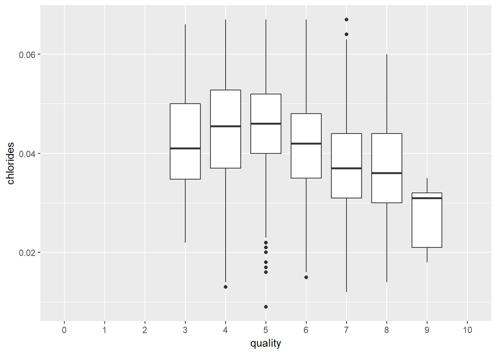

```
##
##  Descriptive statistics by group
## group: 0
## NULL
## --------------------------------------------------------
## group: 1
## NULL
## --------------------------------------------------------
## group: 2
## NULL
## --------------------------------------------------------
## group: 3
##    vars  n mean   sd median trimmed  mad  min  max range skew kurtosis
## X1    1 20 0.05 0.05   0.04    0.04 0.01 0.02 0.24  0.22 3.36    10.91
##      se
## X1 0.01
## --------------------------------------------------------
## group: 4
##    vars   n mean   sd median trimmed  mad  min  max range skew kurtosis se
## X1    1 163 0.05 0.03   0.05    0.05 0.01 0.01 0.29  0.28 5.54    44.69  0
## --------------------------------------------------------
## group: 5
##    vars    n mean   sd median trimmed  mad  min  max range skew kurtosis
## X1    1 1457 0.05 0.03   0.05    0.05 0.01 0.01 0.35  0.34 4.75    31.05
##    se
## X1  0
## --------------------------------------------------------
## group: 6
##    vars    n mean   sd median trimmed  mad  min  max range skew kurtosis
## X1    1 2198 0.05 0.02   0.04    0.04 0.01 0.02 0.26  0.24 4.61    28.76
##    se
## X1  0
## --------------------------------------------------------
## group: 7
##    vars   n mean   sd median trimmed  mad  min  max range skew kurtosis se
## X1    1 880 0.04 0.01   0.04    0.04 0.01 0.01 0.14  0.12 1.99    13.61  0
## --------------------------------------------------------
## group: 8
##    vars   n mean   sd median trimmed  mad  min  max range skew kurtosis se
## X1    1 175 0.04 0.01   0.04    0.04 0.01 0.01 0.12  0.11 2.91    15.56  0
## --------------------------------------------------------
## group: 9
##    vars n mean   sd median trimmed  mad  min  max range  skew kurtosis se
## X1    1 5 0.03 0.01   0.03    0.03 0.01 0.02 0.04  0.02 -0.25    -2.12  0
## --------------------------------------------------------
## group: 10
## NULL
```

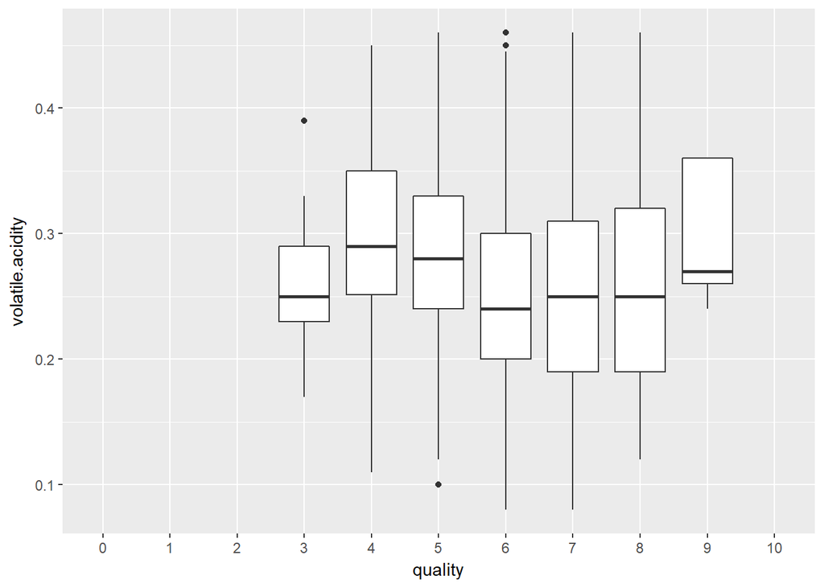

```
##
##  Descriptive statistics by group
## group: 0
## NULL
## --------------------------------------------------------
## group: 1
## NULL
## --------------------------------------------------------
## group: 2
## NULL
## --------------------------------------------------------
## group: 3
##    vars  n mean   sd median trimmed  mad  min  max range skew kurtosis
## X1    1 20 0.33 0.14   0.26    0.32 0.09 0.17 0.64  0.47 0.88    -0.68
##      se
## X1 0.03
## --------------------------------------------------------
## group: 4
##    vars   n mean   sd median trimmed  mad  min max range skew kurtosis
## X1    1 163 0.38 0.17   0.32    0.36 0.11 0.11 1.1  0.99 1.38     2.15
##      se
## X1 0.01
## --------------------------------------------------------
## group: 5
##    vars    n mean  sd median trimmed  mad min max range skew kurtosis se
## X1    1 1457  0.3 0.1   0.28    0.29 0.07 0.1 0.9   0.8 1.43     3.75  0
## --------------------------------------------------------
## group: 6
##    vars    n mean   sd median trimmed  mad  min  max range skew kurtosis
## X1    1 2198 0.26 0.09   0.25    0.25 0.07 0.08 0.96  0.88 1.53     5.03
##    se
## X1  0
## --------------------------------------------------------
## group: 7
##    vars   n mean   sd median trimmed  mad  min  max range skew kurtosis se
## X1    1 880 0.26 0.09   0.25    0.26 0.09 0.08 0.76  0.68 0.81     0.98  0
## --------------------------------------------------------
## group: 8
##    vars   n mean   sd median trimmed mad  min  max range skew kurtosis
## X1    1 175 0.28 0.11   0.26    0.27 0.1 0.12 0.66  0.54 0.97     0.86
##      se
## X1 0.01
## --------------------------------------------------------
## group: 9
##    vars n mean   sd median trimmed  mad  min  max range skew kurtosis   se
## X1    1 5  0.3 0.06   0.27     0.3 0.04 0.24 0.36  0.12 0.21    -2.21 0.03
## --------------------------------------------------------
## group: 10
## NULL
```

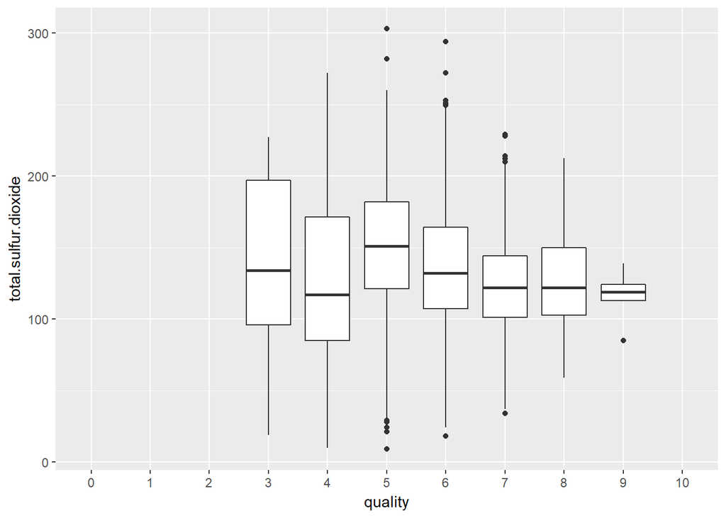

```
##
##  Descriptive statistics by group
## group: 0
## NULL
## --------------------------------------------------------
## group: 1
## NULL
## --------------------------------------------------------
## group: 2
## NULL
## --------------------------------------------------------
## group: 3
##    vars  n  mean     sd median trimmed   mad min max range skew kurtosis
## X1    1 20 170.6 107.76  159.5  159.59 79.32  19 440   421 0.81      0.1
##      se
## X1 24.1
## --------------------------------------------------------
## group: 4
##    vars   n   mean    sd median trimmed   mad min max range skew kurtosis
## X1    1 163 125.28 52.75    117  124.49 62.27  10 272   262 0.21    -0.69
##      se
## X1 4.13
## --------------------------------------------------------
## group: 5
##    vars    n  mean    sd median trimmed   mad min max range  skew kurtosis
## X1    1 1457 150.9 44.09    151  151.36 45.96   9 344   335 -0.03     0.07
##      se
## X1 1.15
## --------------------------------------------------------
## group: 6
##    vars    n   mean    sd median trimmed   mad min max range skew kurtosis
## X1    1 2198 137.05 41.29    132  135.36 41.51  18 294   276 0.36    -0.15
##      se
## X1 0.88
## --------------------------------------------------------
## group: 7
##    vars   n   mean    sd median trimmed   mad min max range skew kurtosis
## X1    1 880 125.11 32.74    122  123.39 32.62  34 229   195  0.5     0.27
##     se
## X1 1.1
## --------------------------------------------------------
## group: 8
##    vars   n   mean    sd median trimmed   mad min   max range skew
## X1    1 175 126.17 33.01    122  124.29 35.58  59 212.5 153.5 0.54
##    kurtosis  se
## X1        0 2.5
## --------------------------------------------------------
## group: 9
##    vars n mean    sd median trimmed mad min max range  skew kurtosis   se
## X1    1 5  116 19.82    119     116 8.9  85 139    54 -0.44    -1.44 8.87
## --------------------------------------------------------
## group: 10
## NULL
```

Não foi possível verificar nenhuma tendência de crescimento o redução nos níveis de *total.sulfur.dioxide*, porém, fica notável no gráfico uma leve diminuição no range de valores com o crescimento da qualidade. Vinho avaliados com qualidade 9 estão dentro de um range de 54 mg/dm<sup>3</sup>.

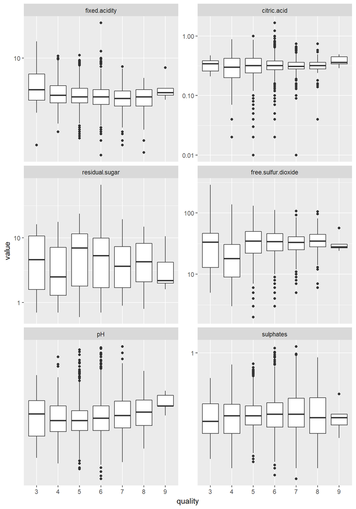

Como foi identificado a partir dos valores de correlação, as demais variáveis não demonstram possuir influência visível na qualidade do vinho. Também é possível notar que algumas delas possuem o mesmo comportamento de *total.sulfur.dioxide* onde existe uma leve diminuição na variação dos valores com o aumento da qualidade.

# Bivariate Analysis

### Talk about some of the relationships you observed in this part of the investigation. How did the feature(s) of interest vary with other features in the dataset?

Após visualizar a relação entre as variáveis de interesse e as demais variáveis foi possível confirmar parte das teorias criadas na anpalise univariada.

Indo de encontro ao esperado *citric.acid* e *residual.sugar* possuem correlação baixa, apenas 0,01 e -0,06, com a qualidade do vinho. Como o vinho foi avaliado por especialistas, existe a possibiilidade do sabor proporcionado pelas substâncias em questão não seja o procurado pelos mesmos.

*Alcohol* e *volatile.acidity* confirmaram as espectativas e mostraram ter correlação com a qualidade do vinho, o primeiro mais que o segundo. Além disso, *density*, *chlorides* e *total.sulfur.dioxide* mostraram ter relação com a qualidade do vinho.

Dos atributos que possuem relação significante com a qualidade, alguns deles possuem alta correlação entre si. Dessa forma, não é indicado utiliza-los em conjunto na previsão da qualidade.

### Did you observe any interesting relationships between the other features (not the main feature(s) of interest)?

*Alcohol* e *density* possuem alta correlação. Esse comportamento é esperado dado que o percentual de álcool influencia a densidade do vinho como é descrito no dicionário dos dados.

### What was the strongest relationship you found?

O atributo com maior relação com a qualidade foi o percentual de álcool no vinho. Tanto numericamente (correlação) quanto visualmente (boxplots), *alcohol* é o candidato mais promissor.

# Multivariate Plots Section

Como foi comentado na análise acima, o atributo com maior correlação com qualidade foi *alcohol*:

```
##
## Call:
## lm(formula = as.numeric(quality) ~ alcohol, data = ww.data)
##
## Residuals:
##     Min      1Q  Median      3Q     Max
## -3.5317 -0.5286  0.0012  0.4996  3.1579
##
## Coefficients:
##             Estimate Std. Error t value Pr(>|t|)
## (Intercept) 3.582009   0.098008   36.55   <2e-16 ***
## alcohol     0.313469   0.009258   33.86   <2e-16 ***
## ---
## Signif. codes:  0 '***' 0.001 '**' 0.01 '*' 0.05 '.' 0.1 ' ' 1
##
## Residual standard error: 0.7973 on 4896 degrees of freedom
## Multiple R-squared:  0.1897, Adjusted R-squared:  0.1896
## F-statistic:  1146 on 1 and 4896 DF,  p-value: < 2.2e-16
```

O R<sup>2</sup> do modelo criado mostra que o atributo *alcohol* consegue explicar aproximadamente 19% da variação da qualidade. Sendo assim, é interessante verificar se a utilização de outros atributo em conjunto com com *alcohol* podem ajudar na previsão.

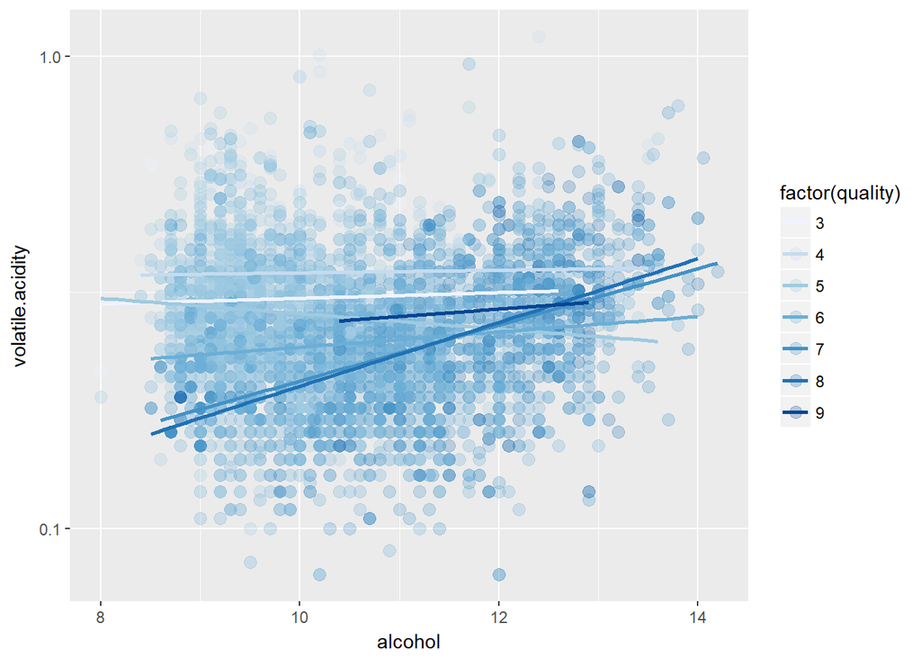

```
##
## Call:
## lm(formula = as.numeric(quality) ~ alcohol + volatile.acidity,
##     data = ww.data)
##
## Residuals:
##     Min      1Q  Median      3Q     Max
## -3.3873 -0.4931 -0.0414  0.4970  3.1429
##
## Coefficients:
##                   Estimate Std. Error t value Pr(>|t|)
## (Intercept)       4.017282   0.097933   41.02   <2e-16 ***
## alcohol           0.324447   0.008987   36.10   <2e-16 ***
## volatile.acidity -1.979194   0.109719  -18.04   <2e-16 ***
## ---
## Signif. codes:  0 '***' 0.001 '**' 0.01 '*' 0.05 '.' 0.1 ' ' 1
##
## Residual standard error: 0.7721 on 4895 degrees of freedom
## Multiple R-squared:  0.2402, Adjusted R-squared:  0.2399
## F-statistic: 773.9 on 2 and 4895 DF,  p-value: < 2.2e-16
```

No caso de *volatile.acidity*, é possível notar que os pontos mais claros (menor qualidade) estão mais concetrados para valores maiores de *volatile.acidity* e menores de *alcohol*. Já os vinhos com maior qualidade parecem estar concentrados na área com maiores valores das duas variáveis. O modelo criado confirma que a segunda variável não ajudar tanto, aumentando apenas em 5% o R<sup>2</sup>. As linhas de regressão ajudam a perceber que é visualmente mais simples diferenciar os níveis de qualidade usando *volatile.acidity* para as variantes de vinho com percentual de álcool abaixo de 11%.

Realizando a mesma análise para os demais atributos selecionados:

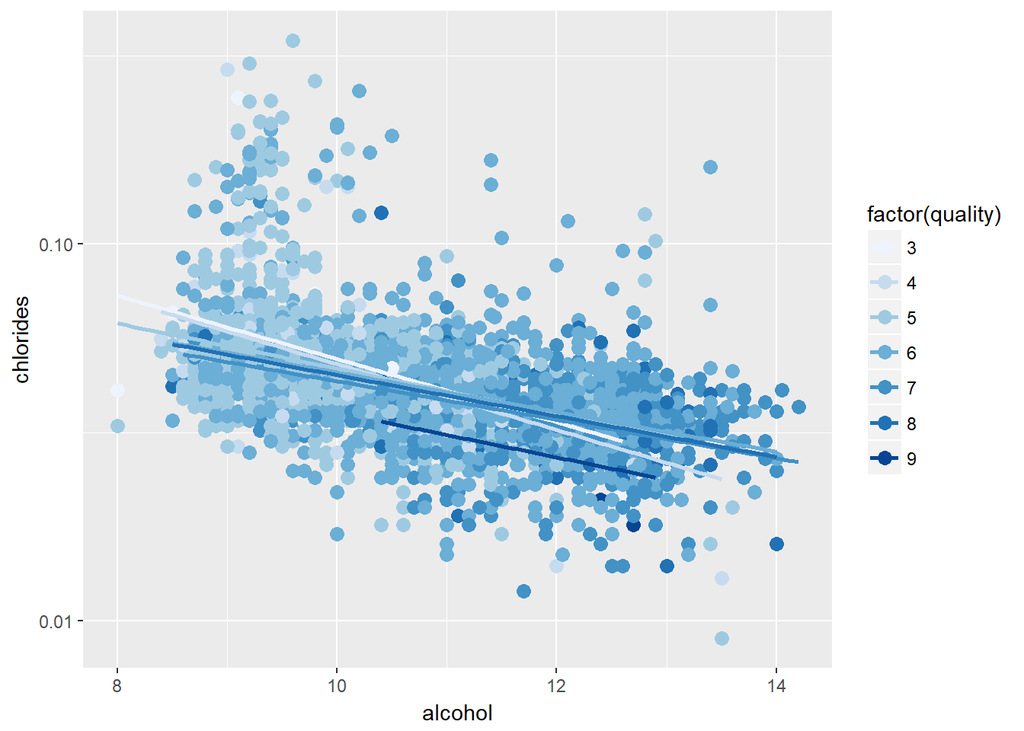

```
##
## Call:
## lm(formula = as.numeric(quality) ~ alcohol + chlorides, data = ww.data)
##
## Residuals:
##     Min      1Q  Median      3Q     Max
## -3.5575 -0.5179 -0.0143  0.4913  3.1295
##
## Coefficients:
##              Estimate Std. Error t value Pr(>|t|)
## (Intercept)  3.861231   0.116382  33.177  < 2e-16 ***
## alcohol      0.297669   0.009906  30.051  < 2e-16 ***
## chlorides   -2.470822   0.557945  -4.428  9.7e-06 ***
## ---
## Signif. codes:  0 '***' 0.001 '**' 0.01 '*' 0.05 '.' 0.1 ' ' 1
##
## Residual standard error: 0.7958 on 4895 degrees of freedom
## Multiple R-squared:  0.193,  Adjusted R-squared:  0.1926
## F-statistic: 585.2 on 2 and 4895 DF,  p-value: < 2.2e-16
```

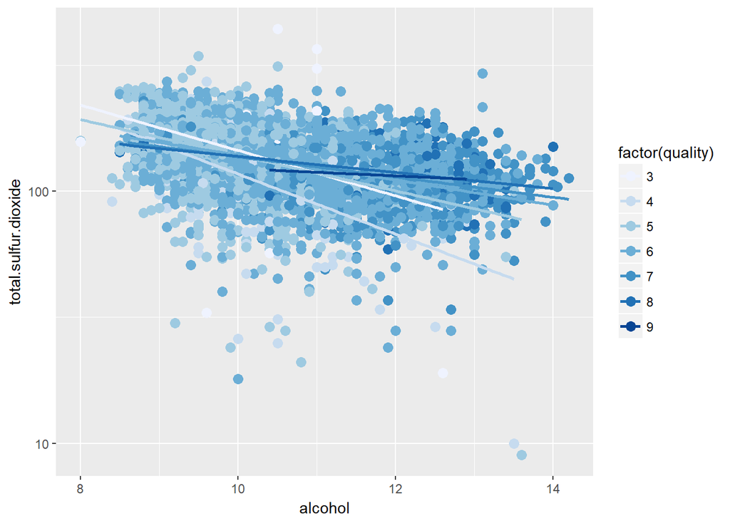

```
##
## Call:
## lm(formula = as.numeric(quality) ~ alcohol + total.sulfur.dioxide,
##     data = ww.data)
##
## Residuals:
##     Min      1Q  Median      3Q     Max
## -3.4845 -0.5274 -0.0063  0.4918  3.1667
##
## Coefficients:
##                       Estimate Std. Error t value Pr(>|t|)
## (Intercept)          3.4185087  0.1333095  25.643   <2e-16 ***
## alcohol              0.3218800  0.0103584  31.074   <2e-16 ***
## total.sulfur.dioxide 0.0005426  0.0002999   1.809   0.0705 .
## ---
## Signif. codes:  0 '***' 0.001 '**' 0.01 '*' 0.05 '.' 0.1 ' ' 1
##
## Residual standard error: 0.7971 on 4895 degrees of freedom
## Multiple R-squared:  0.1903, Adjusted R-squared:  0.1899
## F-statistic: 575.1 on 2 and 4895 DF,  p-value: < 2.2e-16
```

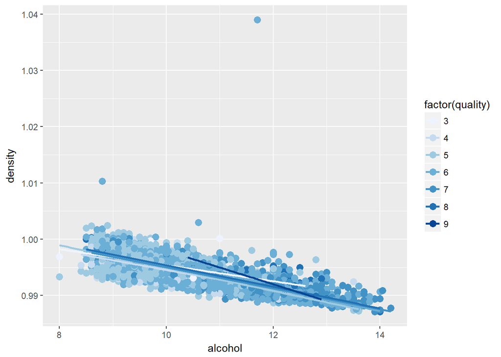

```
##
## Call:
## lm(formula = as.numeric(quality) ~ alcohol + density, data = ww.data)
##
## Residuals:
##     Min      1Q  Median      3Q     Max
## -3.5670 -0.5242 -0.0003  0.4881  3.0898
##
## Coefficients:
##              Estimate Std. Error t value Pr(>|t|)
## (Intercept) -21.49170    6.16503  -3.486 0.000494 ***
## alcohol       0.36036    0.01478  24.389  < 2e-16 ***
## density      24.72842    6.07937   4.068 4.82e-05 ***
## ---
## Signif. codes:  0 '***' 0.001 '**' 0.01 '*' 0.05 '.' 0.1 ' ' 1
##
## Residual standard error: 0.796 on 4895 degrees of freedom
## Multiple R-squared:  0.1925, Adjusted R-squared:  0.1921
## F-statistic: 583.3 on 2 and 4895 DF,  p-value: < 2.2e-16
```

Das variáveis selecionadas apenas *volatile.acidity* conseguiu uma melhora razoável no modelo criado. É interessante citar que com exceção de *total.sulfur.dioxide*, todos os atributos citados se mostraram significantes para o modelo criado. Esse comportamento é confirmado olhando para as linhas de regressão, é difícil separar os níveis de qualidade usando os demais atributos.

Com o intuito de comparar modelos, decidi criar um modelo de regressão linear que usa todas as variáveis existentes no conjunto de dados:

```
##
## Call:
## lm(formula = as.numeric(quality) ~ ., data = ww.data[, -1])
##
## Residuals:
##     Min      1Q  Median      3Q     Max
## -3.8348 -0.4934 -0.0379  0.4637  3.1143
##
## Coefficients:
##                        Estimate Std. Error t value Pr(>|t|)
## (Intercept)           1.512e+02  1.880e+01   8.040 1.11e-15 ***
## fixed.acidity         6.552e-02  2.087e-02   3.139  0.00171 **
## volatile.acidity     -1.863e+00  1.138e-01 -16.373  < 2e-16 ***
## citric.acid           2.209e-02  9.577e-02   0.231  0.81759
## residual.sugar        8.148e-02  7.527e-03  10.825  < 2e-16 ***
## chlorides            -2.473e-01  5.465e-01  -0.452  0.65097
## free.sulfur.dioxide   3.733e-03  8.441e-04   4.422 9.99e-06 ***
## total.sulfur.dioxide -2.857e-04  3.781e-04  -0.756  0.44979
## density              -1.503e+02  1.907e+01  -7.879 4.04e-15 ***
## pH                    6.863e-01  1.054e-01   6.513 8.10e-11 ***
## sulphates             6.315e-01  1.004e-01   6.291 3.44e-10 ***
## alcohol               1.935e-01  2.422e-02   7.988 1.70e-15 ***
## ---
## Signif. codes:  0 '***' 0.001 '**' 0.01 '*' 0.05 '.' 0.1 ' ' 1
##
## Residual standard error: 0.7514 on 4886 degrees of freedom
## Multiple R-squared:  0.2819, Adjusted R-squared:  0.2803
## F-statistic: 174.3 on 11 and 4886 DF,  p-value: < 2.2e-16
```

Quando os modelos são comparados, o aumento do R<sup>2</sup> com a utilização do restante dos atributos é de apenas 4%. Em alguns casos, o pequeno ganho pode não compensar o custo.

# Multivariate Analysis

### Talk about some of the relationships you observed in this part of the investigation. Were there features that strengthened each other in terms of looking at your feature(s) of interest?

Com base no fato de que *alcohol* foi o atributo com maior correlação com a qualidade, a combinação *volatile.acidity* foi o atributo que conseguiu melhores resultados. A utilização dos demais atributos conseguem melhorar o R<sup>2</sup> em 4%.

É interessante citar que mesmo que alguns atributos não melhorem muito os modelos, eles ainda são significantes.

### Were there any interesting or surprising interactions between features?

Não.

### OPTIONAL: Did you create any models with your dataset? Discuss the strengths and limitations of your model.

Sim. Após testar algumas combinações acredito que a combinação mais eficiente foi usando o percentual de álcool e o nível de acidez volátil.

O modelo consegue explicar apenas 24% da variação da qualidade. Em certos contextos esse valor pode ser considerado baixo, entretanto, como a qualidade do vinho calculada por especialistas existe o fator humano que muitas vezes é dificil de ser representado.

# Final Plots and Summary

### Plot One

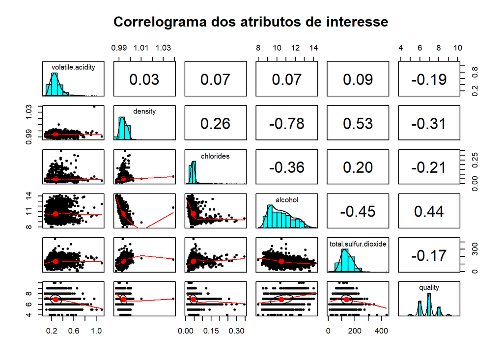

### Description One

Dos 11 atributos apenas 5 possuem correlção razoável com a qualidade do vinho. Alguns deles possuem alta correlação entre si com destaque para *alcohol* e *density* que foram os atributos com maior correlação com a qualidade do vinho. O correlograma fornece uma visão geral do relacionamento entre os atributos de forma que ajuda a focar a análise. No caso, descobrir quais os atributos mais indicados para a previsão da qualidade do vinho.

### Plot Two

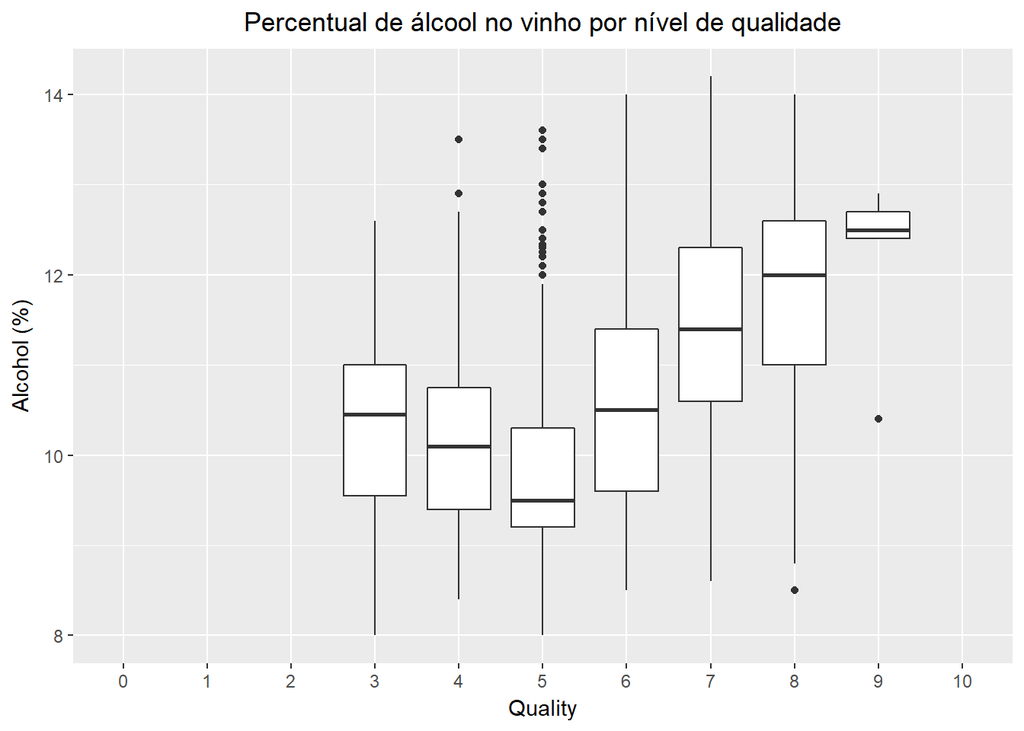

### Plot Three

[output not shown]

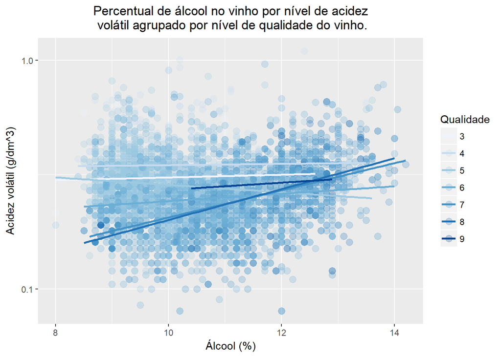

### Description Three

O *scatterplot* é útil na comparação entre mais de 2 atributos numéricos por possibilitar a utilização de canais como cor, tamanho, formato do ponto, etc… para codificar outras informações. No gráfico acima, é possível avaliar o relacionameto entre os dois atributos mais promissores para a previsão da qualidade do vinho. Mesmo não existindo separação totalmente clara entre os níveis de qualidade, das comparações realizadas, *alcohol* e *volatile.acidity* foi que conseguiu separar melhor os níveis de qualidade dos vinhos.

# Reflection

Como não possuia nenhum conhecimento sobre o assunto, foi necessário usar o dicionário de dados com frequência. Incialmente considerando que a qualidade do vinho é fortemente relacionada com os sabor do vinho (doce, pouco ácido, etc…) alguns atributos se destacaram como possíves candidatos a serem utilizados na previsão da qualidade do vinho.

No decorrer da análise notei que considerar apenas o sabor como principal métrica de qualidade não era realista dado que algumas das substâncias diretamente relacionadas com o sabor não apresentaram alta correlação com a qualidade do vinho. No final, o percentual de álcool se destacou entre os demais atributos.

Ainda assim, posso afirmar que nenhum dos atributos obteve correlação alta com a qualidade do vinho. Avaliando os gráficos realizados, é possível que alguns atributos possuam correlação não linear com a qualidade. Um trabalho futuro seria explorar essa possibilidade e a partir disso avaliar a possibilidade de usar modelos não lineares para a previsão da qualidade.

Nessa análise decide prever a qualidade do vinho como um valor numérico. Existe a possibilidade de encarar o problema como um problema de classficação ao invés de regressão.